# Contingency Tables (ELMR Chapter 6)

Biostat 200C

Author

Dr. Jin Zhou @ UCLA

Published

April 28, 2026

Display system information and load `tidyverse` and `faraway` packages

```r
library(tidyverse)
library(faraway)
```

`faraway` package contains the datasets in the ELMR book.

## 1 Two-by-two tables

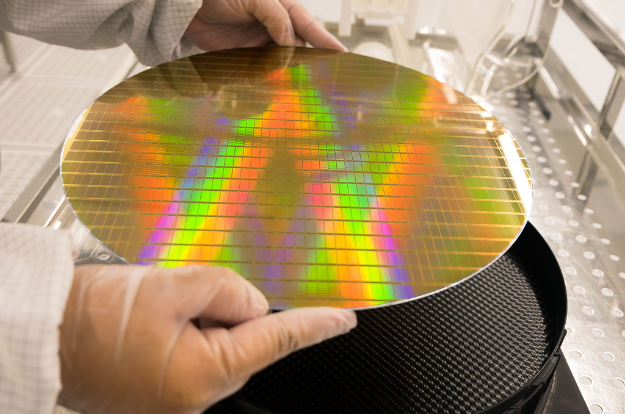

Image source: https://www.gep.com/mind/blog/outlook-for-the-global-semiconductor-silicon-wafer-industry

- Semiconductor wafer quality data. The research question is whether the presence of particles on the die affects the quality of the wafer being produced.

```r
(wafer <- tibble(
  y        = c(320, 14, 80, 36),
  particle = gl(2, 1, length = 4, labels = c("no", "yes")),
  quality  = gl(2, 2, labels = c("good", "bad"))))
```

```
# A tibble: 4 × 3
      y particle quality
  <dbl> <fct>    <fct>
1   320 no       good
2    14 yes      good
3    80 no       bad
4    36 yes      bad
```

This kind of data is conveniently presented as a $2 \times 2$ contingency table.

```r
(ytable <- xtabs(y ~ particle + quality, data = wafer))
```

```
        quality
particle good bad
     no   320  80
     yes   14  36
```

- The usual Pearson $X^2$ test compares the test statistic
  $$X^2 = \sum_{i, j} \frac{(y_{ij} - \widehat \mu_{ij})^2}{\widehat \mu_{ij}},$$
  where
  $$\widehat \mu_{ij} = n \widehat p_i \widehat p_j = n \frac{\sum_j y_{ij}}{n} \frac{\sum_i y_{ij}}{n},$$
  to $\chi_1^2$.

```r
summary(ytable)
```

```
Call: xtabs(formula = y ~ particle + quality, data = wafer)
Number of cases in table: 450
Number of factors: 2
Test for independence of all factors:
    Chisq = 62.81, df = 1, p-value = 2.274e-15
```

- We will analyze this data using 4 different models according to 4 different sampling schemes. They all reach the same conclusion.
  1. We observed the manufacturing process for a certain period of time and observed 450 wafers. The data were then cross-classified. We could use a Poisson model.
  2. We decided to sample 450 wafers. The data were then cross-classified. We could use a multinomial model.
  3. We selected 400 wafers without particles and 50 wafers with particles and then recorded the good or bad outcome. We could use a binomial model.
  4. We selected 400 wafers without particles and 50 wafers with particles that also included, by design, 334 good wafers and 116 bad ones. We could use a hypergeometric model.

### 1.1 Poisson sampling: no margins are fixed

| Particle | Good | Bad | Total |
| --- | --- | --- | --- |
| No | ? | ? | ? |
| Yes | ? | ? | ? |
| **Total** | ? | ? | ? |

### 1.2 Multinomial sampling: only the grand total is fixed

| Particle | Good | Bad | Total |
| --- | --- | --- | --- |
| No | ? | ? | ? |
| Yes | ? | ? | ? |
| **Total** | ? | ? | **450 fixed** |

### 1.3 Product binomial sampling: row totals are fixed

| Particle | Good | Bad | Total |
| --- | --- | --- | --- |
| No | ? | ? | **400 fixed** |
| Yes | ? | ? | **50 fixed** |
| **Total** | ? | ? | **450 fixed** |

### 1.4 Hypergeometric sampling: row and column totals are fixed

| Particle | Good | Bad | Total |
| --- | --- | --- | --- |
| No | ? | ? | **400 fixed** |
| Yes | ? | ? | **50 fixed** |
| **Total** | **334 fixed** | **116 fixed** | **450 fixed** |

### 1.5 Poisson model

- We observe the manufacturing process for a certain period of time and observe 450 wafers. The data are then cross-classified. We model the observed counts by Poisson.

```r
library(gtsummary)
glm(y ~ particle + quality, family = poisson, data = wafer) %>%
  #tbl_regression()
  summary()
```

```
Call:
glm(formula = y ~ particle + quality, family = poisson, data = wafer)

Coefficients:
            Estimate Std. Error z value Pr(>|z|)
(Intercept)   5.6934     0.0572  99.535   <2e-16 ***
particleyes  -2.0794     0.1500 -13.863   <2e-16 ***
qualitybad   -1.0575     0.1078  -9.813   <2e-16 ***
---
Signif. codes:  0 '***' 0.001 '**' 0.01 '*' 0.05 '.' 0.1 ' ' 1

(Dispersion parameter for poisson family taken to be 1)

    Null deviance: 474.10  on 3  degrees of freedom
Residual deviance:  54.03  on 1  degrees of freedom
AIC: 83.774

Number of Fisher Scoring iterations: 5
```

- The null (intercept-only model) model assumes that the rate is constant across particle and quality levels. The analysis of deviance compares $474.10 - 54.03$ to 2 degrees of freedom, indicating null model is rejected in favor of our two predictor Poisson model.
- If we add an interaction term `particle * quality`, the model costs 4 parameters, the same number as the observations. It is equivalent to the full/saturated model. Analysis of deviance compares `54.03` on 1 degree of freedom, indicating the interaction term is highly significant.
- Therefore our conclusion is that presence of particle in the die significantly affects the quality of wafer.

### 1.6 Multinomial model

- If we assume the total sample size is fixed at $n=450$. Then we can model the counts by a multinomial model. We consdier two models
  - $H_1$: one full/saturated model where each cell of the $2 \times 2$ has its own probability $p_{ij}$, and
  - $H_0$: one reduced model that assumes `particle` is independent of `quality`, thus $p_{ij} = p_i p_j$.
- For the full/saturated model $H_1$, the multinomial likelihood is
  $$\frac{n!}{\prod_i \prod_j y_{ij}!} \prod_i \prod_j p_{ij}^{y_{ij}}.$$
  We estimate $p_{ij}$ by the cell proportion (MLE)
  $$\widehat{p}_{ij} = \frac{y_{ij}}{n}.$$
- For the reduced model assuming independence $H_0$, the multinomial likelihood is
  $$\frac{n!}{\prod_i \prod_j y_{ij}!} \prod_i \prod_j (p_i p_j)^{y_{ij}} = \frac{n!}{\prod_i \prod_j y_{ij}!} p_i^{\sum_j y_{ij}} p_j^{\sum_i y_{ij}}.$$
  The MLE is
  $$\widehat{p}_i = \frac{\sum_j y_{ij}}{n}, \quad \widehat{p}_j = \frac{\sum_i y_{ij}}{n}.$$
- The analysis deviance compares the deviance
  $$\begin{eqnarray*}
  D &=& 2 \sum_i \sum_j y_{ij} \log \frac{y_{ij}}{n} - 2 \sum_i \left(\sum_j y_{ij}\right) \log \widehat{p}_i - 2 \sum_j \left(\sum_i y_{ij}\right) \log \widehat{p}_j \\
  &=& 2 \sum_i \sum_j y_{ij} \log \frac{y_{ij}}{n \widehat{p}_i \widehat{p}_j} \\
  &=& 2 \sum_i \sum_j y_{ij} \log \frac{y_{ij}}{\widehat{\mu}_{ij}}
  \end{eqnarray*}$$
  to 1 degree of freedom.

```r
(partp <- xtabs(y ~ particle, data = wafer) %>% prop.table())
```

```
particle
       no       yes
0.8888889 0.1111111
```

```r
(qualp <- xtabs(y ~ quality, data = wafer)  %>% prop.table())
```

```
quality
     good       bad
0.7422222 0.2577778
```

```r
muhat <- 450 * outer(partp, qualp)
ytable <- xtabs(y ~ particle + quality, data = wafer)
2 * sum(ytable * log(ytable / muhat))
```

```
[1] 54.03045
```

- We get the exact same result as the analysis of deviance in the Poisson model.
- This connection between Poisson and multinomial is no surprise due to the following fact. If $Y_1, \ldots, Y_k$ are independent Poisson with means $\lambda_1, \ldots, \lambda_k$, then the joint distribution of $Y_1, \ldots, Y_k \mid \sum_i Y_i = n$ is multinomial with probabilities $p_j = \lambda_j / \sum_i \lambda_i$.

### 1.7 Binomial

- If we view `particle` as a predictor affecting whether a wafer is good quality or bad quality, we end up with an independent binomial model.
- The null (intercept-only) model corresponds to the hypothesis `particle` does not affect quality.

```r
tibble(good     = c(320, 14),
       bad      = c(80, 36),
       particle = c("no", "yes")) %>%
  print() %>%
  glm(cbind(good, bad) ~ 1, family = binomial, data = .) %>%
  summary()
```

```
# A tibble: 2 × 3
   good   bad particle
  <dbl> <dbl> <chr>
1   320    80 no
2    14    36 yes
```

```
Call:
glm(formula = cbind(good, bad) ~ 1, family = binomial, data = .)

Coefficients:
            Estimate Std. Error z value Pr(>|z|)
(Intercept)   1.0576     0.1078   9.813   <2e-16 ***
---
Signif. codes:  0 '***' 0.001 '**' 0.01 '*' 0.05 '.' 0.1 ' ' 1

(Dispersion parameter for binomial family taken to be 1)

    Null deviance: 54.03  on 1  degrees of freedom
Residual deviance: 54.03  on 1  degrees of freedom
AIC: 66.191

Number of Fisher Scoring iterations: 3
```

The alternative model corresponds to the full/saturated model where `particle` is included as a predictor.

- Again we observe the exactly same analysis of deviance inference.
- When there are more than two rows or columns, this model is called the **product binoimal/multinomial model**.

### 1.8 Hypergeometric

- Finally if we fix both row and column marginal totals, the probability of the observed table is
  $$\begin{eqnarray*}
  p(y_{11}, y_{12}, y_{21}, y_{22}) &=& \frac{\binom{y_{1\cdot}}{y_{11}} \binom{y_{2\cdot}}{y_{22}} \binom{y_{\cdot 1}}{y_{21}} \binom{y_{\cdot 2}}{y_{12}}}{\binom{n}{y_{11} \, y_{12} \, y_{21} \, y_{22}}} \\
  &=& \frac{y_{1\cdot}! y_{2\cdot}! y_{\cdot 1}! y_{\cdot 2}!}{y_{11}! y_{12}! y_{21}! y_{22}! n!} \\
  &=& \frac{\binom{y_{1 \cdot}}{y_{11}} \binom{y_{2 \cdot}}{y_{\cdot 1} - y_{11}}}{\binom{n}{y_{\cdot 1}}}.
  \end{eqnarray*}$$
- Under the null hypothesis that `particle` is not associated with `quality`, the **Fisher’s exact test** calculates the p-value by summing over the probabilities of tables with more extreme observations
  $$\sum_{y_{11} \ge 320} p(y_{11}, y_{12}, y_{21}, y_{22}).$$

```r
fisher.test(ytable)
```

```
    Fisher's Exact Test for Count Data

data:  ytable
p-value = 2.955e-13
alternative hypothesis: true odds ratio is not equal to 1
95 percent confidence interval:
  5.090628 21.544071
sample estimates:
odds ratio
  10.21331
```

The odds ratio is
$$\frac{\pi_{\text{no particle}} / (1 - \pi_{\text{no particle}})}{\pi_{\text{particle}} / (1 - \pi_{\text{particle}})} = \frac{y_{11} y_{22}}{y_{12} y_{21}}$$

```r
(320 * 36) / (14 * 80)
```

```
[1] 10.28571
```

## 2 Larger two-way tables

- The `haireye` data set contains data on 592 statistics students cross-classifed by hair and eye color.

```r
haireye <- as_tibble(haireye) %>%
  print(n = Inf)
```

```
# A tibble: 16 × 3
       y eye   hair
   <dbl> <fct> <fct>
 1     5 green BLACK
 2    29 green BROWN
 3    14 green RED
 4    16 green BLOND
 5    15 hazel BLACK
 6    54 hazel BROWN
 7    14 hazel RED
 8    10 hazel BLOND
 9    20 blue  BLACK
10    84 blue  BROWN
11    17 blue  RED
12    94 blue  BLOND
13    68 brown BLACK
14   119 brown BROWN
15    26 brown RED
16     7 brown BLOND
```

```r
(haireye_table <- xtabs(y ~ hair + eye, data = haireye))
```

```
       eye
hair    green hazel blue brown
  BLACK     5    15   20    68
  BROWN    29    54   84   119
  RED      14    14   17    26
  BLOND    16    10   94     7
```

- Graphical summary of the contingency table by a **mosaic plot**. If `eye` and `hair` are independent, we expect to see a grid.

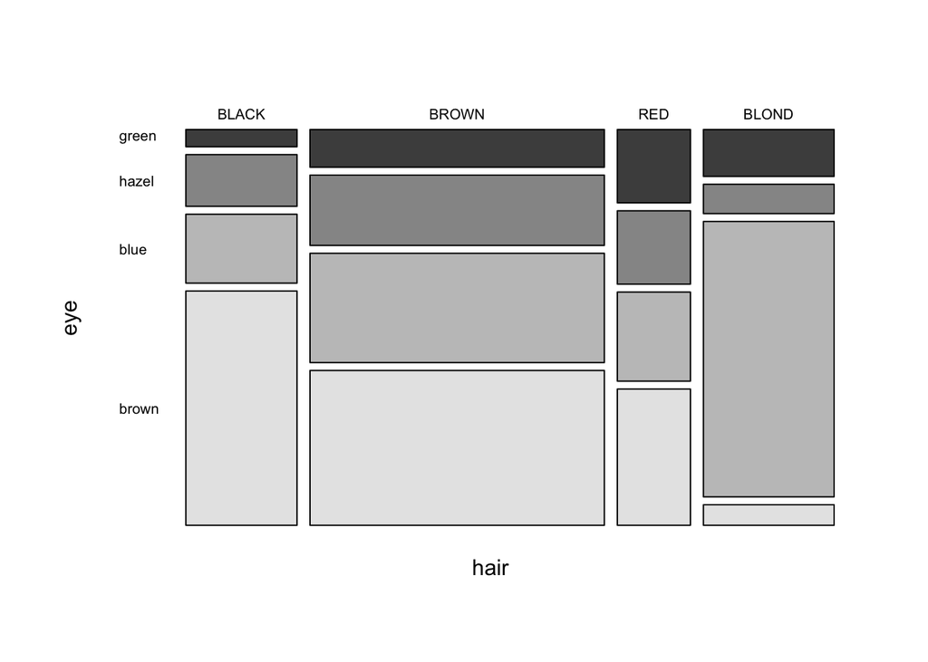

```r
mosaicplot(haireye_table, color = TRUE, main = NULL, las = 1)
```

- Pearson $X^2$ test for independence yields

```r
summary(haireye_table)
```

```
Call: xtabs(formula = y ~ hair + eye, data = haireye)
Number of cases in table: 592
Number of factors: 2
Test for independence of all factors:
    Chisq = 138.29, df = 9, p-value = 2.325e-25
```

- We fit a Poisson GLM:

```r
    modc <- glm(y ~ hair + eye, family = poisson, data = haireye)
    summary(modc)
```

```
Call:
glm(formula = y ~ hair + eye, family = poisson, data = haireye)

Coefficients:
            Estimate Std. Error z value Pr(>|z|)
(Intercept)   2.4575     0.1523  16.136  < 2e-16 ***
hairBROWN     0.9739     0.1129   8.623  < 2e-16 ***
hairRED      -0.4195     0.1528  -2.745  0.00604 **
hairBLOND     0.1621     0.1309   1.238  0.21569
eyehazel      0.3737     0.1624   2.301  0.02139 *
eyeblue       1.2118     0.1424   8.510  < 2e-16 ***
eyebrown      1.2347     0.1420   8.694  < 2e-16 ***
---
Signif. codes:  0 '***' 0.001 '**' 0.01 '*' 0.05 '.' 0.1 ' ' 1

(Dispersion parameter for poisson family taken to be 1)

    Null deviance: 453.31  on 15  degrees of freedom
Residual deviance: 146.44  on  9  degrees of freedom
AIC: 241.04

Number of Fisher Scoring iterations: 5
```

which clearly shows a lack of fit. The interaction model is equivalent to the full/saturated model. Therefore we see strong evidence for the dependence between `eye` and `hair`.

## 3 Three-way contingency tables

- The `femsoke` data records female smokers and non-smokers, their age group, and whether the subjects were dead or still alive after 20 years.

```r
femsmoke <- as_tibble(femsmoke) %>%
  print(n = Inf)
```

```
# A tibble: 28 × 4
       y smoker dead  age
   <dbl> <fct>  <fct> <fct>
 1     2 yes    yes   18-24
 2     1 no     yes   18-24
 3     3 yes    yes   25-34
 4     5 no     yes   25-34
 5    14 yes    yes   35-44
 6     7 no     yes   35-44
 7    27 yes    yes   45-54
 8    12 no     yes   45-54
 9    51 yes    yes   55-64
10    40 no     yes   55-64
11    29 yes    yes   65-74
12   101 no     yes   65-74
```

[output cut: 16 more lines]

There are three factors `smoker`, `dead`, and `age`. If we just classify over `smoker` and `dead`

```r
(ct <- xtabs(y ~ smoker + dead, data = femsmoke))
```

```
      dead
smoker yes  no
   yes 139 443
   no  230 502
```

```r
prop.table(ct, 1)
```

```
      dead
smoker       yes        no
   yes 0.2388316 0.7611684
   no  0.3142077 0.6857923
```

we see significantly higher percentage of non-smokers died than smokers.

```r
summary(ct)
```

```
Call: xtabs(formula = y ~ smoker + dead, data = femsmoke)
Number of cases in table: 1314
Number of factors: 2
Test for independence of all factors:
    Chisq = 9.121, df = 1, p-value = 0.002527
```

- However `smoke` status is confounded with the `age` group. Smokers are more concentrated in the younger groups and younger people are more likely to live for another 20 years.

```r
prop.table(xtabs(y ~ smoker + age, data = femsmoke), 2)
```

```
      age
smoker     18-24     25-34     35-44     45-54     55-64     65-74       75+
   yes 0.4700855 0.4412811 0.4739130 0.6250000 0.4872881 0.2181818 0.1688312
   no  0.5299145 0.5587189 0.5260870 0.3750000 0.5127119 0.7818182 0.8311688
```

- The odds ratios in all age groups are:

```r
ct3 <- xtabs(y ~ smoker + dead + age, data = femsmoke)
apply(ct3, 3, function (x) (x[1, 1] * x[2, 2]) / (x[1, 2] * x[2, 1]))
```

```
   18-24    25-34    35-44    45-54    55-64    65-74      75+
2.301887 0.753719 2.400000 1.441748 1.613672 1.148515      NaN
```

- The Cochran-Mantel-Haenszel (CMH) tests independence in $2 \times 2$ tables across $K$ strata. It compares the statistic
  $$\frac{(|\sum_k y_{11k} - \sum_k \mathbb{E}y_{11k}| - 1/2)^2}{\sum_k \operatorname{Var} y_{11k}},$$
  where the expectation and variance are computed under the null hypothesis of independence in each stratum, to asymptotic null distribution $\chi_1^2$ and calculate the p-value by exact test.

```r
mantelhaen.test(ct3, exact = TRUE)
```

```
    Exact conditional test of independence in 2 x 2 x k tables

data:  ct3
S = 139, p-value = 0.01591
alternative hypothesis: true common odds ratio is not equal to 1
95 percent confidence interval:
 1.068889 2.203415
sample estimates:
common odds ratio
         1.530256
```

### 3.1 Mutual independence model

- Under mutual independence,
  $$p_{ijk} = p_i p_j p_k$$
  so
  $$\mathbb{E} Y_{ijk} = n p_{ijk}$$
  and
  $$\log \mathbb{E} Y_{ijk} = \log n + \log p_i + \log p_j + \log p_k.$$
  So the main effect-only model corresponds to the mutual independence model.
- We can test independence by the Pearson $X^2$ test

```r
summary(ct3)
```

```
Call: xtabs(formula = y ~ smoker + dead + age, data = femsmoke)
Number of cases in table: 1314
Number of factors: 3
Test for independence of all factors:
    Chisq = 790.6, df = 19, p-value = 2.14e-155
```

or by a Poisson GLM

```r
modi <- glm(y ~ smoker + dead + age, family = poisson, data = femsmoke)
summary(modi)
```

```
Call:
glm(formula = y ~ smoker + dead + age, family = poisson, data = femsmoke)

Coefficients:
            Estimate Std. Error z value Pr(>|z|)
(Intercept)  2.67778    0.10702  25.021  < 2e-16 ***
smokerno     0.22931    0.05554   4.129 3.64e-05 ***
deadno       0.94039    0.06139  15.319  < 2e-16 ***
age25-34     0.87618    0.11003   7.963 1.67e-15 ***
age35-44     0.67591    0.11356   5.952 2.65e-09 ***
age45-54     0.57536    0.11556   4.979 6.40e-07 ***
age55-64     0.70166    0.11307   6.206 5.45e-10 ***
age65-74     0.34377    0.12086   2.844  0.00445 **
age75+      -0.41837    0.14674  -2.851  0.00436 **
---
Signif. codes:  0 '***' 0.001 '**' 0.01 '*' 0.05 '.' 0.1 ' ' 1

(Dispersion parameter for poisson family taken to be 1)

    Null deviance: 1193.9  on 27  degrees of freedom
Residual deviance:  735.0  on 19  degrees of freedom
AIC: 887.2

Number of Fisher Scoring iterations: 6
```

Both suggest a lack of fit.

```r
modi %>% tbl_regression(exponentiate = TRUE, intercept = TRUE)
```

| **Characteristic** | **IRR** | **95% CI** | **p-value** |
| --- | --- | --- | --- |
| (Intercept) | 14.6 | 11.7, 17.9 | <0.001 |
| smoker |  |  |  |
| yes | — | — |  |
| no | 1.26 | 1.13, 1.40 | <0.001 |
| dead |  |  |  |
| yes | — | — |  |
| no | 2.56 | 2.27, 2.89 | <0.001 |
| age |  |  |  |
| 18-24 | — | — |  |
| 25-34 | 2.40 | 1.94, 2.99 | <0.001 |
| 35-44 | 1.97 | 1.58, 2.46 | <0.001 |
| 45-54 | 1.78 | 1.42, 2.24 | <0.001 |
| 55-64 | 2.02 | 1.62, 2.53 | <0.001 |
| 65-74 | 1.41 | 1.11, 1.79 | 0.004 |
| 75+ | 0.66 | 0.49, 0.88 | 0.004 |

Abbreviations: CI = Confidence Interval, IRR = Incidence Rate Ratio

The exponentiated coefficients are just marginal proportions

```r
c(1, 1.26) / (1 + 1.26)
```

```
[1] 0.4424779 0.5575221
```

```r
prop.table(xtabs(y ~ smoker, femsmoke))
```

```
smoker
      yes        no
0.4429224 0.5570776
```

### 3.2 Joint independence

- If we assume the first two variables are dependent, and jointly independent of the third. Then
  $$p_{ijk} = p_{ij} p_k$$
  and
  $$\log \mathbb{E} Y_{ijk} = \log n + \log p_{ij} + \log p_k.$$
- It leads to a log-linear model with just one interaction

```r
    glm(y ~ smoker * dead + age, family = poisson, data = femsmoke) %>%
    summary()
```

```
Call:
glm(formula = y ~ smoker * dead + age, family = poisson, data = femsmoke)

Coefficients:
                Estimate Std. Error z value Pr(>|z|)
(Intercept)      2.51582    0.12239  20.555  < 2e-16 ***
smokerno         0.50361    0.10743   4.688 2.76e-06 ***
deadno           1.15910    0.09722  11.922  < 2e-16 ***
age25-34         0.87618    0.11003   7.963 1.67e-15 ***
age35-44         0.67591    0.11356   5.952 2.65e-09 ***
age45-54         0.57536    0.11556   4.979 6.40e-07 ***
age55-64         0.70166    0.11307   6.206 5.45e-10 ***
age65-74         0.34377    0.12086   2.844  0.00445 **
age75+          -0.41837    0.14674  -2.851  0.00436 **
smokerno:deadno -0.37858    0.12566  -3.013  0.00259 **
---
Signif. codes:  0 '***' 0.001 '**' 0.01 '*' 0.05 '.' 0.1 ' ' 1

(Dispersion parameter for poisson family taken to be 1)

    Null deviance: 1193.9  on 27  degrees of freedom
Residual deviance:  725.8  on 18  degrees of freedom
AIC: 880

Number of Fisher Scoring iterations: 6
```

```
It improves the fit, but still not enough.
```

### 3.3 Conditional independence

- Let $P_{ij \mid k}$ be the probability that an observation falls in $(i, j)$-cell given that we know the third variables takes value $k$. If we assume that first two variables are independent give value of the third. Then
  $$p_{ijk} = p_{ij\mid k} p_k = p_{i\mid k} p_{j \mid k} p_k = \frac{p_{ik} p_{jk}}{p_k}.$$
  and
  $$\log \mathbb{E} Y_{ijk} = \log n + \log p_{ik} + \log p_{jk} - \log p_k.$$
- It leads to a model with two interaction terms

```r
glm(y ~ smoker * age + dead * age, family = poisson, data = femsmoke) %>%
  summary()
```

```
Call:
glm(formula = y ~ smoker * age + dead * age, family = poisson,
    data = femsmoke)

Coefficients:
                    Estimate Std. Error z value Pr(>|z|)
(Intercept)          0.34377    0.58563   0.587 0.557199
smokerno             0.11980    0.18523   0.647 0.517785
age25-34             0.91760    0.68737   1.335 0.181895
age35-44             1.95402    0.62882   3.107 0.001887 **
age45-54             2.84979    0.60950   4.676 2.93e-06 ***
age55-64             3.44819    0.59868   5.760 8.43e-09 ***
age65-74             3.00134    0.61023   4.918 8.73e-07 ***
age75+               2.22118    0.64799   3.428 0.000609 ***
deadno               3.63759    0.58490   6.219 5.00e-10 ***
smokerno:age25-34    0.11616    0.22078   0.526 0.598789
smokerno:age35-44   -0.01536    0.22749  -0.068 0.946172
smokerno:age45-54   -0.63063    0.23414  -2.693 0.007074 **
smokerno:age55-64   -0.06894    0.22643  -0.304 0.760765
smokerno:age65-74    1.15649    0.26427   4.376 1.21e-05 ***
smokerno:age75+      1.47413    0.35617   4.139 3.49e-05 ***
age25-34:deadno     -0.10756    0.68613  -0.157 0.875435
age35-44:deadno     -1.33977    0.62810  -2.133 0.032920 *
age45-54:deadno     -2.17125    0.61128  -3.552 0.000382 ***
age55-64:deadno     -3.17171    0.59999  -5.286 1.25e-07 ***
age65-74:deadno     -4.94977    0.61512  -8.047 8.49e-16 ***
age75+:deadno      -26.30450 5776.51889  -0.005 0.996367
---
Signif. codes:  0 '***' 0.001 '**' 0.01 '*' 0.05 '.' 0.1 ' ' 1

(Dispersion parameter for poisson family taken to be 1)

    Null deviance: 1193.9378  on 27  degrees of freedom
Residual deviance:    8.3269  on  7  degrees of freedom
AIC: 184.52

Number of Fisher Scoring iterations: 17
```

This model fits data pretty well.

- Significance of predictors

```r
glm(y ~ smoker * age + dead * age, family = poisson, data = femsmoke) %>%
drop1(test = "Chi")
```

```
Single term deletions

Model:
y ~ smoker * age + dead * age
           Df Deviance    AIC    LRT  Pr(>Chi)
<none>            8.33 184.52
smoker:age  6   101.83 266.03  93.51 < 2.2e-16 ***
age:dead    6   641.50 805.69 633.17 < 2.2e-16 ***
---
Signif. codes:  0 '***' 0.001 '**' 0.01 '*' 0.05 '.' 0.1 ' ' 1
```

### 3.4 Uniform association

- If we consider a model with all two-way interactions
  $$\log \mathbb{E}Y_{ijk} = \log n + \log p_i + \log p_j + \log p_k + \log p_{ij} + \log p_{ik} + \log p_{jk}.$$
- There is no simple interpretation in terms of independence.

```r
modu <- glm(y ~ (smoker + age + dead)^2, family = poisson, data = femsmoke)
summary(modu)
```

```
Call:
glm(formula = y ~ (smoker + age + dead)^2, family = poisson,
    data = femsmoke)

Coefficients:
                    Estimate Std. Error z value Pr(>|z|)
(Intercept)          0.54284    0.58736   0.924 0.355384
smokerno            -0.29666    0.25324  -1.171 0.241401
age25-34             0.92902    0.68381   1.359 0.174273
age35-44             1.94048    0.62486   3.105 0.001900 **
age45-54             2.76845    0.60657   4.564 5.02e-06 ***
age55-64             3.37507    0.59550   5.668 1.45e-08 ***
age65-74             2.86586    0.60894   4.706 2.52e-06 ***
age75+               2.02211    0.64955   3.113 0.001851 **
deadno               3.43271    0.59014   5.817 6.00e-09 ***
smokerno:age25-34    0.11752    0.22091   0.532 0.594749
smokerno:age35-44    0.01268    0.22800   0.056 0.955654
smokerno:age45-54   -0.56538    0.23585  -2.397 0.016522 *
smokerno:age55-64    0.08512    0.23573   0.361 0.718030
smokerno:age65-74    1.49088    0.30039   4.963 6.93e-07 ***
smokerno:age75+      1.89060    0.39582   4.776 1.78e-06 ***
smokerno:deadno      0.42741    0.17703   2.414 0.015762 *
age25-34:deadno     -0.12006    0.68655  -0.175 0.861178
age35-44:deadno     -1.34112    0.62857  -2.134 0.032874 *
age45-54:deadno     -2.11336    0.61210  -3.453 0.000555 ***
age55-64:deadno     -3.18077    0.60057  -5.296 1.18e-07 ***
age65-74:deadno     -5.08798    0.61951  -8.213  < 2e-16 ***
age75+:deadno      -27.31727 8839.01146  -0.003 0.997534
---
Signif. codes:  0 '***' 0.001 '**' 0.01 '*' 0.05 '.' 0.1 ' ' 1

(Dispersion parameter for poisson family taken to be 1)

    Null deviance: 1193.9378  on 27  degrees of freedom
Residual deviance:    2.3809  on  6  degrees of freedom
AIC: 180.58

Number of Fisher Scoring iterations: 18
```

- If we compute the odds ratio for each age group

```r
xtabs(fitted(modu) ~ smoker + dead + age, data = femsmoke) %>%
apply(3, function(x) (x[1, 1] * x[2, 2]) / (x[1, 2] * x[2, 1]))
```

```
   18-24    25-34    35-44    45-54    55-64    65-74      75+
1.533275 1.533275 1.533275 1.533275 1.533275 1.533275 1.533275
```

Thus the name uniform association model.

- The odds ratio can also be extracted from the coefficients

```r
exp(coef(modu)['smokerno:deadno'])
```

```
smokerno:deadno
       1.533275
```

### 3.5 Model selection

- We can start from the saturated model (3-way interaction) and use the analysis of deviance to see how much we can reduce the model.

```r
glm(y ~ smoker * age * dead, family = poisson, data = femsmoke) %>%
  step(test = "Chi") %>%
  drop1(test = "Chi")
```

```
Start:  AIC=190.19
y ~ smoker * age * dead

                  Df Deviance    AIC    LRT Pr(>Chi)
- smoker:age:dead  6   2.3809 180.58 2.3809   0.8815
<none>                 0.0000 190.19

Step:  AIC=180.58
y ~ smoker + age + dead + smoker:age + smoker:dead + age:dead

              Df Deviance    AIC    LRT Pr(>Chi)
<none>               2.38 180.58
- smoker:dead  1     8.33 184.52   5.95  0.01475 *
- smoker:age   6    92.63 258.83  90.25  < 2e-16 ***
- age:dead     6   632.30 798.49 629.92  < 2e-16 ***
---
Signif. codes:  0 '***' 0.001 '**' 0.01 '*' 0.05 '.' 0.1 ' ' 1
```

```
Single term deletions

Model:
y ~ smoker + age + dead + smoker:age + smoker:dead + age:dead
            Df Deviance    AIC    LRT Pr(>Chi)
<none>             2.38 180.58
smoker:age   6    92.63 258.83  90.25  < 2e-16 ***
smoker:dead  1     8.33 184.52   5.95  0.01475 *
age:dead     6   632.30 798.49 629.92  < 2e-16 ***
---
Signif. codes:  0 '***' 0.001 '**' 0.01 '*' 0.05 '.' 0.1 ' ' 1
```

The interaction term `smoker:dead` is weakly significant in the final model. This corresponds to the test of conditional independence between `smoke` and `dead` given `age` group. The p-value is very similar to that from the CMH test.

### 3.6 Binomial

- It also makes intuitive sense to model life status as the outcome depending on perdictors `smoker` and `age`.

```r
# glm(dead ~ smoker * age, family = binomial, weights = y, data = femsmoke) %>%
#   summary()
glm(matrix(femsmoke$y, ncol = 2) ~ smoker * age, family = binomial, femsmoke[1:14, ]) %>%
  step(test = "Chi") %>%
  summary()
```

```
Start:  AIC=75
matrix(femsmoke$y, ncol = 2) ~ smoker * age

             Df Deviance    AIC    LRT Pr(>Chi)
- smoker:age  6   2.3809 65.377 2.3809   0.8815
<none>            0.0000 74.996

Step:  AIC=65.38
matrix(femsmoke$y, ncol = 2) ~ smoker + age

         Df Deviance    AIC    LRT Pr(>Chi)
<none>          2.38  65.38
- smoker  1     8.33  69.32   5.95  0.01475 *
- age     6   632.30 683.29 629.92  < 2e-16 ***
---
Signif. codes:  0 '***' 0.001 '**' 0.01 '*' 0.05 '.' 0.1 ' ' 1
```

```
Call:
glm(formula = matrix(femsmoke$y, ncol = 2) ~ smoker + age, family = binomial,
    data = femsmoke[1:14, ])

Coefficients:
              Estimate Std. Error z value Pr(>|z|)
(Intercept)    -3.4327     0.5901  -5.817 6.00e-09 ***
smokerno       -0.4274     0.1770  -2.414 0.015762 *
age25-34        0.1201     0.6865   0.175 0.861178
age35-44        1.3411     0.6286   2.134 0.032874 *
age45-54        2.1134     0.6121   3.453 0.000555 ***
age55-64        3.1808     0.6006   5.296 1.18e-07 ***
age65-74        5.0880     0.6195   8.213  < 2e-16 ***
age75+         27.8073 11293.1430   0.002 0.998035
---
Signif. codes:  0 '***' 0.001 '**' 0.01 '*' 0.05 '.' 0.1 ' ' 1

(Dispersion parameter for binomial family taken to be 1)

    Null deviance: 641.4963  on 13  degrees of freedom
Residual deviance:   2.3809  on  6  degrees of freedom
AIC: 65.377

Number of Fisher Scoring iterations: 20
```

- The final model retains only main effects. This is equivalent to the uniform association model. The deviance is exactly the same.